# ELAIS-N2 master catalogue

## Preparation of Spitzer datafusion SWIRE data

The Spitzer catalogues were produced by the datafusion team are available in `dmu0_DataFusion-Spitzer`. Lucia told that the magnitudes are aperture corrected.

In the catalouge, we keep:

We keep:

- The internal identifier (this one is only in HeDaM data);
- The position;
- The fluxes in aperture 2 (1.9 arcsec) for IRAC bands.
- The Kron flux;
- The stellarity in each band

A query of the position in the Spitzer heritage archive show that the ELAIS-N1 images were observed in 2004. Let's take this as epoch. Is ELAIS N2 different?

We do not use the MIPS fluxes as they will be extracted on MIPS maps using XID+.

```python
from herschelhelp_internal import git_version
print("This notebook was run with herschelhelp_internal version: \n{}".format(git_version()))
```

```
This notebook was run with herschelhelp_internal version:
44f1ae0 (Thu Nov 30 18:27:54 2017 +0000)
```

```python
%matplotlib inline
#%config InlineBackend.figure_format = 'svg'

import matplotlib.pyplot as plt
plt.rc('figure', figsize=(10, 6))

from collections import OrderedDict
import os

from astropy import units as u
from astropy.coordinates import SkyCoord
from astropy.table import Column, Table
import numpy as np

from herschelhelp_internal.flagging import  gaia_flag_column
from herschelhelp_internal.masterlist import nb_astcor_diag_plot, remove_duplicates
from herschelhelp_internal.utils import astrometric_correction, flux_to_mag
```

```python
OUT_DIR =  os.environ.get('TMP_DIR', "./data_tmp")
try:
    os.makedirs(OUT_DIR)
except FileExistsError:
    pass

RA_COL = "swire_ra"
DEC_COL = "swire_dec"
```

## I - Column selection

```python
imported_columns = OrderedDict({
        'internal_id': "swire_intid",
        'ra_spitzer': "swire_ra",
        'dec_spitzer': "swire_dec",
        'flux_ap2_36': "f_ap_irac_i1",
        'uncf_ap2_36': "ferr_ap_irac_i1",
        'flux_kr_36': "f_irac_i1",
        'uncf_kr_36': "ferr_irac_i1",
        'stell_36': "swire_stellarity",
        'flux_ap2_45': "f_ap_irac_i2",
        'uncf_ap2_45': "ferr_ap_irac_i2",
        'flux_kr_45': "f_irac_i2",
        'uncf_kr_45': "ferr_irac_i2",
        #'stell_45': "swire_stellarity_irac2",
        'flux_ap2_58': "f_ap_irac_i3",
        'uncf_ap2_58': "ferr_ap_irac_i3",
        'flux_kr_58': "f_irac_i3",
        'uncf_kr_58': "ferr_irac_i3",
        #'stell_58': "swire_stellarity_irac3",
        'flux_ap2_80': "f_ap_irac_i4",
        'uncf_ap2_80': "ferr_ap_irac_i4",
        'flux_kr_80': "f_irac_i4",
        'uncf_kr_80': "ferr_irac_i4",
        #'stell_80': "swire_stellarity_irac4",
    })


catalogue = Table.read("../../dmu0/dmu0_DataFusion-Spitzer/data/DF-SWIRE_ELAIS-N2.fits")[list(imported_columns)]
for column in imported_columns:
    catalogue[column].name = imported_columns[column]

epoch = 2004

# Clean table metadata
catalogue.meta = None
```

```python
# Adding magnitude and band-flag columns
for col in catalogue.colnames:
    if col.startswith('f_'):
        errcol = "ferr{}".format(col[1:])

        magnitude, error = flux_to_mag(
            np.array(catalogue[col])/1.e6, np.array(catalogue[errcol])/1.e6)
        # Note that some fluxes are 0.

        catalogue.add_column(Column(magnitude, name="m{}".format(col[1:])))
        catalogue.add_column(Column(error, name="m{}".format(errcol[1:])))

        # Band-flag column
        if "ap" not in col:
            catalogue.add_column(Column(np.zeros(len(catalogue), dtype=bool), name="flag{}".format(col[1:])))
```

```python
catalogue[:10].show_in_notebook()
```

<Table masked=True length=10>

| idx | swire_intid | swire_ra deg | swire_dec deg | f_ap_irac_i1 uJy | ferr_ap_irac_i1 uJy | f_irac_i1 uJy | ferr_irac_i1 uJy | swire_stellarity | f_ap_irac_i2 uJy | ferr_ap_irac_i2 uJy | f_irac_i2 uJy | ferr_irac_i2 uJy | f_ap_irac_i3 uJy | ferr_ap_irac_i3 uJy | f_irac_i3 uJy | ferr_irac_i3 uJy | f_ap_irac_i4 uJy | ferr_ap_irac_i4 uJy | f_irac_i4 uJy | ferr_irac_i4 uJy | m_ap_irac_i1 | merr_ap_irac_i1 | m_irac_i1 | merr_irac_i1 | flag_irac_i1 | m_ap_irac_i2 | merr_ap_irac_i2 | m_irac_i2 | merr_irac_i2 | … |
| --- | --- | --- | --- | --- | --- | --- | --- | --- | --- | --- | --- | --- | --- | --- | --- | --- | --- | --- | --- | --- | --- | --- | --- | --- | --- | --- | --- | --- | --- | --- |
| 0 | 1233719 | 248.275301 | 39.720129 | 33.69 | 4.36 | 70.03 | 4.95 | 0.95 | nan | nan | nan | nan | nan | nan | nan | nan | nan | nan | nan | nan | 20.0812474725 | 0.140510829705 | 19.2867896841 | 0.0767441698351 | False | nan | nan | nan | nan | … |
| 1 | 1234159 | 248.269131 | 39.728339 | 32.79 | 2.07 | 110.68 | 3.3 | 0.0 | nan | nan | nan | nan | nan | nan | nan | nan | nan | nan | nan | nan | 20.1106464583 | 0.0685414438502 | 18.7898271238 | 0.0323719685192 | False | nan | nan | nan | nan | … |
| 2 | 1234334 | 248.266851 | 39.731289 | 28.35 | 2.05 | 98.61 | 3.08 | 0.01 | nan | nan | nan | nan | nan | nan | nan | nan | nan | nan | nan | nan | 20.2686173419 | 0.0785100253882 | 18.915197603 | 0.0339120526382 | False | nan | nan | nan | nan | … |
| 3 | 1234300 | 248.273391 | 39.733599 | 131.74 | 2.43 | 147.16 | 2.41 | 0.36 | nan | nan | nan | nan | 117.81 | 10.61 | 109.83 | 8.62 | nan | nan | nan | nan | 18.6007058522 | 0.0200268633487 | 18.4805255521 | 0.0177808117251 | False | nan | nan | nan | nan | … |
| 4 | 1234511 | 248.264271 | 39.734869 | 33.28 | 2.36 | 98.88 | 3.68 | 0.47 | nan | nan | nan | nan | nan | nan | nan | nan | nan | nan | nan | nan | 20.094541706 | 0.076993312597 | 18.9122288556 | 0.0404076581059 | False | nan | nan | nan | nan | … |
| 5 | 1234350 | 248.272581 | 39.734379 | 30.41 | 1.38 | 36.36 | 1.67 | 0.88 | nan | nan | nan | nan | nan | nan | nan | nan | nan | nan | nan | nan | 20.1924589496 | 0.049270501893 | 19.9984403136 | 0.0498674219457 | False | nan | nan | nan | nan | … |
| 6 | 1234418 | 248.270721 | 39.734939 | 228.3 | 4.1 | 168.46 | 3.0 | 0.99 | nan | nan | nan | nan | nan | nan | nan | nan | nan | nan | nan | nan | 18.0037352213 | 0.0194985476982 | 18.3337580091 | 0.0193352048811 | False | nan | nan | nan | nan | … |
| 7 | 1234420 | 248.272611 | 39.735839 | 246.53 | 3.02 | 179.53 | 2.18 | 1.0 | nan | nan | nan | nan | nan | nan | nan | nan | nan | nan | nan | nan | 17.9203255607 | 0.0133003015388 | 18.2646574228 | 0.0131838964316 | False | nan | nan | nan | nan | … |
| 8 | 1234485 | 248.272171 | 39.737719 | 40.38 | 1.46 | 53.78 | 1.98 | 0.04 | nan | nan | nan | nan | nan | nan | nan | nan | nan | nan | nan | nan | 19.8845842135 | 0.039256435338 | 19.5734480053 | 0.039973181209 | False | nan | nan | nan | nan | … |
| 9 | 1234494 | 248.274841 | 39.739139 | 24.64 | 1.2 | 24.34 | 1.29 | 0.71 | nan | nan | nan | nan | nan | nan | nan | nan | nan | nan | nan | nan | 20.4208982413 | 0.0528767632187 | 20.4341985653 | 0.0575431267107 | False | nan | nan | nan | nan | … |

## II - Removal of duplicated sources

We remove duplicated objects from the input catalogues.

```python
SORT_COLS = ['ferr_ap_irac_i1', 'ferr_ap_irac_i2', 'ferr_ap_irac_i3', 'ferr_ap_irac_i4']
FLAG_NAME = "swire_flag_cleaned"

nb_orig_sources = len(catalogue)

catalogue = remove_duplicates(catalogue, RA_COL, DEC_COL, sort_col=SORT_COLS,flag_name=FLAG_NAME)

nb_sources = len(catalogue)

print("The initial catalogue had {} sources.".format(nb_orig_sources))
print("The cleaned catalogue has {} sources ({} removed).".format(nb_sources, nb_orig_sources - nb_sources))
print("The cleaned catalogue has {} sources flagged as having been cleaned".format(np.sum(catalogue[FLAG_NAME])))
```

```
The initial catalogue had 273650 sources.
The cleaned catalogue has 273392 sources (258 removed).
The cleaned catalogue has 258 sources flagged as having been cleaned
```

## III - Astrometry correction

We match the astrometry to the Gaia one. We limit the Gaia catalogue to sources with a g band flux between the 30th and the 70th percentile. Some quick tests show that this give the lower dispersion in the results.

```python
gaia = Table.read("../../dmu0/dmu0_GAIA/data/GAIA_ELAIS-N2.fits")
gaia_coords = SkyCoord(gaia['ra'], gaia['dec'])
```

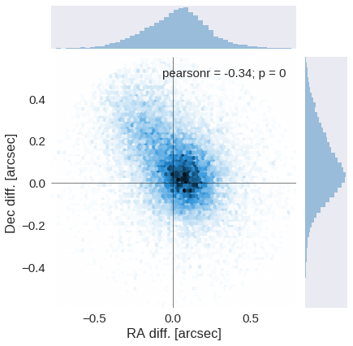

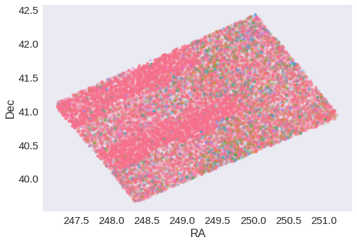

```python
nb_astcor_diag_plot(catalogue[RA_COL], catalogue[DEC_COL],
                    gaia_coords.ra, gaia_coords.dec)
```

```python
delta_ra, delta_dec =  astrometric_correction(
    SkyCoord(catalogue[RA_COL], catalogue[DEC_COL]),
    gaia_coords
)

print("RA correction: {}".format(delta_ra))
print("Dec correction: {}".format(delta_dec))
```

```
RA correction: -0.03311454242975742 arcsec
Dec correction: -0.06647202361023119 arcsec
```

```python
catalogue[RA_COL] +=  delta_ra.to(u.deg)
catalogue[DEC_COL] += delta_dec.to(u.deg)
```

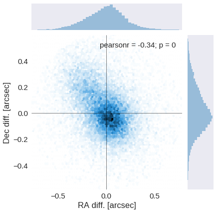

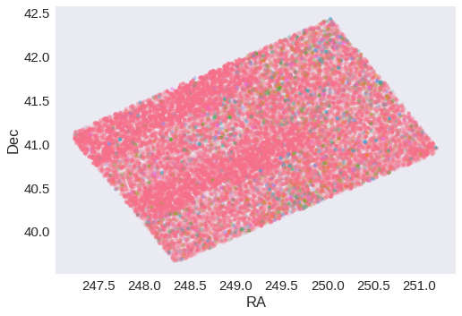

```python
nb_astcor_diag_plot(catalogue[RA_COL], catalogue[DEC_COL],
                    gaia_coords.ra, gaia_coords.dec)
```

## IV - Flagging Gaia objects

```python
catalogue.add_column(
    gaia_flag_column(SkyCoord(catalogue[RA_COL], catalogue[DEC_COL]), epoch, gaia)
)
```

```python
GAIA_FLAG_NAME = "swire_flag_gaia"

catalogue['flag_gaia'].name = GAIA_FLAG_NAME
print("{} sources flagged.".format(np.sum(catalogue[GAIA_FLAG_NAME] > 0)))
```

```
22663 sources flagged.
```

## V - Flagging objects near bright stars

# VI - Saving to disk

```python
catalogue.write("{}/SWIRE.fits".format(OUT_DIR), overwrite=True)
```